# Project: Investigate a Dataset - [TMDb movie data]

- Introduction
- Data Wrangling
- Exploratory Data Analysis
- Conclusions

## Introduction

### Question(s) for Analysis

> **01**: Which genres are most produced?  
> **02**: Top 20 directors who directes most movies?  
> **03**: Top 20 actors who acted in films?  
> **04**: Top 20 production compaines with higher releases?  
> **05**: Top&lower 10 movies in budget, revenue, profit, rating, popularity?  
> **06**: Which year&month has the most releases?  
> **07**: which year&month has the higher revenue?  
> **08**: What is the average of budget, revenue, profit for each year?  
> **09**: What is the type of correlation between Revenue and Popularity, Rating, Runtime?  
> **10**: What is the type of correlation between Runtime and Budget, Revenue, Profit, Rating?

```python
# Use this cell to set up import statements for all of the packages that you
#   plan to use.
import pandas as pd
import numpy as np
import matplotlib.pylab as plt
import seaborn as sns
%matplotlib inline
# Remember to include a 'magic word' so that your visualizations are plotted
#   inline with the notebook. See this page for more:
#   http://ipython.readthedocs.io/en/stable/interactive/magics.html
```

```python
# Upgrade pandas to use dataframe.explode() function.
# !pip install --upgrade pandas
```

# Data Wrangling

#### At this part we are doing the following steps

- Data Loading
- Data Scaning (Info, Describe, Uniqueness, Duplication, ...)
- Data Cleaning

```python
# Load your data and print out a few lines. Perform operations to inspect data
#   types and look for instances of missing or possibly errant data.
df = pd.read_csv("Data/tmdb-movies.csv")
df.head()
```

|  | id | imdb_id | popularity | budget | revenue | original_title | cast | homepage | director | tagline | ... | overview | runtime | genres | production_companies | release_date | vote_count | vote_average | release_year | budget_adj | revenue_adj |
| --- | --- | --- | --- | --- | --- | --- | --- | --- | --- | --- | --- | --- | --- | --- | --- | --- | --- | --- | --- | --- | --- |
| 0 | 135397 | tt0369610 | 32.985763 | 150000000 | 1513528810 | Jurassic World | Chris Pratt\|Bryce Dallas Howard\|Irrfan Khan\|Vi... | http://www.jurassicworld.com/ | Colin Trevorrow | The park is open. | ... | Twenty-two years after the events of Jurassic ... | 124 | Action\|Adventure\|Science Fiction\|Thriller | Universal Studios\|Amblin Entertainment\|Legenda... | 6/9/15 | 5562 | 6.5 | 2015 | 1.379999e+08 | 1.392446e+09 |
| 1 | 76341 | tt1392190 | 28.419936 | 150000000 | 378436354 | Mad Max: Fury Road | Tom Hardy\|Charlize Theron\|Hugh Keays-Byrne\|Nic... | http://www.madmaxmovie.com/ | George Miller | What a Lovely Day. | ... | An apocalyptic story set in the furthest reach... | 120 | Action\|Adventure\|Science Fiction\|Thriller | Village Roadshow Pictures\|Kennedy Miller Produ... | 5/13/15 | 6185 | 7.1 | 2015 | 1.379999e+08 | 3.481613e+08 |
| 2 | 262500 | tt2908446 | 13.112507 | 110000000 | 295238201 | Insurgent | Shailene Woodley\|Theo James\|Kate Winslet\|Ansel... | http://www.thedivergentseries.movie/#insurgent | Robert Schwentke | One Choice Can Destroy You | ... | Beatrice Prior must confront her inner demons ... | 119 | Adventure\|Science Fiction\|Thriller | Summit Entertainment\|Mandeville Films\|Red Wago... | 3/18/15 | 2480 | 6.3 | 2015 | 1.012000e+08 | 2.716190e+08 |
| 3 | 140607 | tt2488496 | 11.173104 | 200000000 | 2068178225 | Star Wars: The Force Awakens | Harrison Ford\|Mark Hamill\|Carrie Fisher\|Adam D... | http://www.starwars.com/films/star-wars-episod... | J.J. Abrams | Every generation has a story. | ... | Thirty years after defeating the Galactic Empi... | 136 | Action\|Adventure\|Science Fiction\|Fantasy | Lucasfilm\|Truenorth Productions\|Bad Robot | 12/15/15 | 5292 | 7.5 | 2015 | 1.839999e+08 | 1.902723e+09 |
| 4 | 168259 | tt2820852 | 9.335014 | 190000000 | 1506249360 | Furious 7 | Vin Diesel\|Paul Walker\|Jason Statham\|Michelle ... | http://www.furious7.com/ | James Wan | Vengeance Hits Home | ... | Deckard Shaw seeks revenge against Dominic Tor... | 137 | Action\|Crime\|Thriller | Universal Pictures\|Original Film\|Media Rights ... | 4/1/15 | 2947 | 7.3 | 2015 | 1.747999e+08 | 1.385749e+09 |

5 rows × 21 columns

#### Vision:

> This data set conains a column for movies release date, which needs to convert its type.

```python
df.tail()
```

|  | id | imdb_id | popularity | budget | revenue | original_title | cast | homepage | director | tagline | ... | overview | runtime | genres | production_companies | release_date | vote_count | vote_average | release_year | budget_adj | revenue_adj |
| --- | --- | --- | --- | --- | --- | --- | --- | --- | --- | --- | --- | --- | --- | --- | --- | --- | --- | --- | --- | --- | --- |
| 10861 | 21 | tt0060371 | 0.080598 | 0 | 0 | The Endless Summer | Michael Hynson\|Robert August\|Lord 'Tally Ho' B... | NaN | Bruce Brown | NaN | ... | The Endless Summer, by Bruce Brown, is one of ... | 95 | Documentary | Bruce Brown Films | 6/15/66 | 11 | 7.4 | 1966 | 0.000000 | 0.0 |
| 10862 | 20379 | tt0060472 | 0.065543 | 0 | 0 | Grand Prix | James Garner\|Eva Marie Saint\|Yves Montand\|Tosh... | NaN | John Frankenheimer | Cinerama sweeps YOU into a drama of speed and ... | ... | Grand Prix driver Pete Aron is fired by his te... | 176 | Action\|Adventure\|Drama | Cherokee Productions\|Joel Productions\|Douglas ... | 12/21/66 | 20 | 5.7 | 1966 | 0.000000 | 0.0 |
| 10863 | 39768 | tt0060161 | 0.065141 | 0 | 0 | Beregis Avtomobilya | Innokentiy Smoktunovskiy\|Oleg Efremov\|Georgi Z... | NaN | Eldar Ryazanov | NaN | ... | An insurance agent who moonlights as a carthie... | 94 | Mystery\|Comedy | Mosfilm | 1/1/66 | 11 | 6.5 | 1966 | 0.000000 | 0.0 |
| 10864 | 21449 | tt0061177 | 0.064317 | 0 | 0 | What's Up, Tiger Lily? | Tatsuya Mihashi\|Akiko Wakabayashi\|Mie Hama\|Joh... | NaN | Woody Allen | WOODY ALLEN STRIKES BACK! | ... | In comic Woody Allen's film debut, he took the... | 80 | Action\|Comedy | Benedict Pictures Corp. | 11/2/66 | 22 | 5.4 | 1966 | 0.000000 | 0.0 |
| 10865 | 22293 | tt0060666 | 0.035919 | 19000 | 0 | Manos: The Hands of Fate | Harold P. Warren\|Tom Neyman\|John Reynolds\|Dian... | NaN | Harold P. Warren | It's Shocking! It's Beyond Your Imagination! | ... | A family gets lost on the road and stumbles up... | 74 | Horror | Norm-Iris | 11/15/66 | 15 | 1.5 | 1966 | 127642.279154 | 0.0 |

5 rows × 21 columns

#### Vision:

> It is clear that we have some values of 0's in budget and revenue columns, which at most means that this data isn't provided. So i decide to remove those rows.

```python
df.info()
```

```
<class 'pandas.core.frame.DataFrame'>
RangeIndex: 10866 entries, 0 to 10865
Data columns (total 21 columns):
 #   Column                Non-Null Count  Dtype
---  ------                --------------  -----
 0   id                    10866 non-null  int64
 1   imdb_id               10856 non-null  object
 2   popularity            10866 non-null  float64
 3   budget                10866 non-null  int64
 4   revenue               10866 non-null  int64
 5   original_title        10866 non-null  object
 6   cast                  10790 non-null  object
 7   homepage              2936 non-null   object
 8   director              10822 non-null  object
 9   tagline               8042 non-null   object
 10  keywords              9373 non-null   object
 11  overview              10862 non-null  object
 12  runtime               10866 non-null  int64
 13  genres                10843 non-null  object
 14  production_companies  9836 non-null   object
 15  release_date          10866 non-null  object
 16  vote_count            10866 non-null  int64
 17  vote_average          10866 non-null  float64
 18  release_year          10866 non-null  int64
 19  budget_adj            10866 non-null  float64
 20  revenue_adj           10866 non-null  float64
dtypes: float64(4), int64(6), object(11)
memory usage: 1.7+ MB
```

#### Vision:

> **Respect to NAN counts:** It is clear that "homepage" column has alot of NAN values, also "imdb_id", "cast", "director", "tagline", "keywords", "overview", "genres", "production_companies" columns have NAN values.  
> So i decide to drop columns like "imdb_id", "homepage", "tagline", "keywords", "overview", "budget_adj", "revenue_adj", after that drop rows which contains NAN.

> **Respect to data types:** There is one column needs to convert its type, this column is "release_date".

```python
df.describe()
```

|  | id | popularity | budget | revenue | runtime | vote_count | vote_average | release_year | budget_adj | revenue_adj |
| --- | --- | --- | --- | --- | --- | --- | --- | --- | --- | --- |
| count | 10866.000000 | 10866.000000 | 1.086600e+04 | 1.086600e+04 | 10866.000000 | 10866.000000 | 10866.000000 | 10866.000000 | 1.086600e+04 | 1.086600e+04 |
| mean | 66064.177434 | 0.646441 | 1.462570e+07 | 3.982332e+07 | 102.070863 | 217.389748 | 5.974922 | 2001.322658 | 1.755104e+07 | 5.136436e+07 |
| std | 92130.136561 | 1.000185 | 3.091321e+07 | 1.170035e+08 | 31.381405 | 575.619058 | 0.935142 | 12.812941 | 3.430616e+07 | 1.446325e+08 |
| min | 5.000000 | 0.000065 | 0.000000e+00 | 0.000000e+00 | 0.000000 | 10.000000 | 1.500000 | 1960.000000 | 0.000000e+00 | 0.000000e+00 |
| 25% | 10596.250000 | 0.207583 | 0.000000e+00 | 0.000000e+00 | 90.000000 | 17.000000 | 5.400000 | 1995.000000 | 0.000000e+00 | 0.000000e+00 |
| 50% | 20669.000000 | 0.383856 | 0.000000e+00 | 0.000000e+00 | 99.000000 | 38.000000 | 6.000000 | 2006.000000 | 0.000000e+00 | 0.000000e+00 |
| 75% | 75610.000000 | 0.713817 | 1.500000e+07 | 2.400000e+07 | 111.000000 | 145.750000 | 6.600000 | 2011.000000 | 2.085325e+07 | 3.369710e+07 |
| max | 417859.000000 | 32.985763 | 4.250000e+08 | 2.781506e+09 | 900.000000 | 9767.000000 | 9.200000 | 2015.000000 | 4.250000e+08 | 2.827124e+09 |

#### Vision:

> This data set shows data about movies for 56 years (1960-2015).

```python
df.nunique()
```

```
id                      10865
imdb_id                 10855
popularity              10814
budget                    557
revenue                  4702
original_title          10571
cast                    10719
homepage                 2896
director                 5067
tagline                  7997
keywords                 8804
overview                10847
runtime                   247
genres                   2039
production_companies     7445
release_date             5909
vote_count               1289
vote_average               72
release_year               56
budget_adj               2614
revenue_adj              4840
dtype: int64
```

```python
df.duplicated().sum()
```

```
1
```

```python
df.shape
```

```
(10866, 21)
```

```python
# Check for number of missed budget and revenue values
df.query('budget == 0')['id'].count(), df.query('revenue == 0')['id'].count()
```

```
(5696, 6016)
```

#### Visoin:

> This data set contains more the its half values missed in "budget" and "revenue" columns.

### Data Cleaning

> **Tip**: We can see Nan values in some rows, so i'll drop them.  
> Also we have trivial columns, i'll drop them too.  
> Respect to budget and revenue 0 values, i'll replace them by numpy.NAN.

```python
# Let's drop those columns that we don't need.
columns_to_drop = [
    "imdb_id",
    "homepage",
    "tagline",
    "keywords",
    "overview",
    "budget_adj",
    "revenue_adj",
]
df.drop(columns_to_drop, axis=1, inplace=True)
df.shape
```

```
(10866, 14)
```

#### Vision:

> After useless columns dropped, we have only 14 columns remaining.

```python
# Now we need to drop Nan rows
df.dropna(axis=0, inplace=True)
df.shape
```

```
(9773, 14)
```

#### Vision:

> After NAN values dropped from rows, we have 9773 rows. 1,093 rows dropped.

```python
# Remove duplicates
df.drop_duplicates(inplace=True)
df.duplicated().sum()
```

```
0
```

#### Vision:

> No more duplicates in data.

```python
# Replace budget and revenue 0 values by numpy.NAN
df['budget'] = df['budget'].replace(0, np.NAN)
df['revenue'] = df['revenue'].replace(0, np.NAN)
df.tail()
```

|  | id | popularity | budget | revenue | original_title | cast | director | runtime | genres | production_companies | release_date | vote_count | vote_average | release_year |
| --- | --- | --- | --- | --- | --- | --- | --- | --- | --- | --- | --- | --- | --- | --- |
| 10861 | 21 | 0.080598 | NaN | NaN | The Endless Summer | Michael Hynson\|Robert August\|Lord 'Tally Ho' B... | Bruce Brown | 95 | Documentary | Bruce Brown Films | 6/15/66 | 11 | 7.4 | 1966 |
| 10862 | 20379 | 0.065543 | NaN | NaN | Grand Prix | James Garner\|Eva Marie Saint\|Yves Montand\|Tosh... | John Frankenheimer | 176 | Action\|Adventure\|Drama | Cherokee Productions\|Joel Productions\|Douglas ... | 12/21/66 | 20 | 5.7 | 1966 |
| 10863 | 39768 | 0.065141 | NaN | NaN | Beregis Avtomobilya | Innokentiy Smoktunovskiy\|Oleg Efremov\|Georgi Z... | Eldar Ryazanov | 94 | Mystery\|Comedy | Mosfilm | 1/1/66 | 11 | 6.5 | 1966 |
| 10864 | 21449 | 0.064317 | NaN | NaN | What's Up, Tiger Lily? | Tatsuya Mihashi\|Akiko Wakabayashi\|Mie Hama\|Joh... | Woody Allen | 80 | Action\|Comedy | Benedict Pictures Corp. | 11/2/66 | 22 | 5.4 | 1966 |
| 10865 | 22293 | 0.035919 | 19000.0 | NaN | Manos: The Hands of Fate | Harold P. Warren\|Tom Neyman\|John Reynolds\|Dian... | Harold P. Warren | 74 | Horror | Norm-Iris | 11/15/66 | 15 | 1.5 | 1966 |

> **Hint**: Replacing budget and revenue 0's by NAN to drop it later.

```python
df.head()
```

|  | id | popularity | budget | revenue | original_title | cast | director | runtime | genres | production_companies | release_date | vote_count | vote_average | release_year |
| --- | --- | --- | --- | --- | --- | --- | --- | --- | --- | --- | --- | --- | --- | --- |
| 0 | 135397 | 32.985763 | 150000000.0 | 1.513529e+09 | Jurassic World | Chris Pratt\|Bryce Dallas Howard\|Irrfan Khan\|Vi... | Colin Trevorrow | 124 | Action\|Adventure\|Science Fiction\|Thriller | Universal Studios\|Amblin Entertainment\|Legenda... | 6/9/15 | 5562 | 6.5 | 2015 |
| 1 | 76341 | 28.419936 | 150000000.0 | 3.784364e+08 | Mad Max: Fury Road | Tom Hardy\|Charlize Theron\|Hugh Keays-Byrne\|Nic... | George Miller | 120 | Action\|Adventure\|Science Fiction\|Thriller | Village Roadshow Pictures\|Kennedy Miller Produ... | 5/13/15 | 6185 | 7.1 | 2015 |
| 2 | 262500 | 13.112507 | 110000000.0 | 2.952382e+08 | Insurgent | Shailene Woodley\|Theo James\|Kate Winslet\|Ansel... | Robert Schwentke | 119 | Adventure\|Science Fiction\|Thriller | Summit Entertainment\|Mandeville Films\|Red Wago... | 3/18/15 | 2480 | 6.3 | 2015 |
| 3 | 140607 | 11.173104 | 200000000.0 | 2.068178e+09 | Star Wars: The Force Awakens | Harrison Ford\|Mark Hamill\|Carrie Fisher\|Adam D... | J.J. Abrams | 136 | Action\|Adventure\|Science Fiction\|Fantasy | Lucasfilm\|Truenorth Productions\|Bad Robot | 12/15/15 | 5292 | 7.5 | 2015 |
| 4 | 168259 | 9.335014 | 190000000.0 | 1.506249e+09 | Furious 7 | Vin Diesel\|Paul Walker\|Jason Statham\|Michelle ... | James Wan | 137 | Action\|Crime\|Thriller | Universal Pictures\|Original Film\|Media Rights ... | 4/1/15 | 2947 | 7.3 | 2015 |

```python
# Fix datatypes of columns
df['release_date'] = pd.to_datetime(df['release_date'])
df.info()
```

```
<class 'pandas.core.frame.DataFrame'>
Int64Index: 9772 entries, 0 to 10865
Data columns (total 14 columns):
 #   Column                Non-Null Count  Dtype
---  ------                --------------  -----
 0   id                    9772 non-null   int64
 1   popularity            9772 non-null   float64
 2   budget                5021 non-null   float64
 3   revenue               4750 non-null   float64
 4   original_title        9772 non-null   object
 5   cast                  9772 non-null   object
 6   director              9772 non-null   object
 7   runtime               9772 non-null   int64
 8   genres                9772 non-null   object
 9   production_companies  9772 non-null   object
 10  release_date          9772 non-null   datetime64[ns]
 11  vote_count            9772 non-null   int64
 12  vote_average          9772 non-null   float64
 13  release_year          9772 non-null   int64
dtypes: datetime64[ns](1), float64(4), int64(4), object(5)
memory usage: 1.1+ MB
```

```python
# Convert columns data type if we can to make our data frame lighter.
df['id'] = df['id'].astype('int32')
df['runtime'] = df['runtime'].astype('int16')
df['vote_count'] = df['vote_count'].astype('int16')
df['release_year'] = df['release_year'].astype('int16')
df['popularity'] = df['popularity'].astype('float16')
df['vote_average'] = df['vote_average'].astype('float16')

# Check for changed data types
df.info()
# Check for columns ranges of data
df.describe()
```

```
<class 'pandas.core.frame.DataFrame'>
Int64Index: 9772 entries, 0 to 10865
Data columns (total 14 columns):
 #   Column                Non-Null Count  Dtype
---  ------                --------------  -----
 0   id                    9772 non-null   int32
 1   popularity            9772 non-null   float16
 2   budget                5021 non-null   float64
 3   revenue               4750 non-null   float64
 4   original_title        9772 non-null   object
 5   cast                  9772 non-null   object
 6   director              9772 non-null   object
 7   runtime               9772 non-null   int16
 8   genres                9772 non-null   object
 9   production_companies  9772 non-null   object
 10  release_date          9772 non-null   datetime64[ns]
 11  vote_count            9772 non-null   int16
 12  vote_average          9772 non-null   float16
 13  release_year          9772 non-null   int16
dtypes: datetime64[ns](1), float16(2), float64(2), int16(3), int32(1), object(5)
memory usage: 820.7+ KB
```

|  | id | popularity | budget | revenue | runtime | vote_count | vote_average | release_year |
| --- | --- | --- | --- | --- | --- | --- | --- | --- |
| count | 9772.000000 | 9772.000000 | 5.021000e+03 | 4.750000e+03 | 9772.000000 | 9772.000000 | 9772.000000 | 9772.000000 |
| mean | 63189.640810 | 0.694336 | 3.148929e+07 | 9.099524e+07 | 102.926627 | 239.312014 | 5.960938 | 2000.878428 |
| std | 90718.059987 | 1.037109 | 3.920818e+07 | 1.632905e+08 | 27.877432 | 603.011504 | 0.913086 | 13.036794 |
| min | 5.000000 | 0.000188 | 1.000000e+00 | 2.000000e+00 | 0.000000 | 10.000000 | 1.500000 | 1960.000000 |
| 25% | 10221.500000 | 0.232727 | 6.300000e+06 | 8.501551e+06 | 90.000000 | 18.000000 | 5.398438 | 1994.000000 |
| 50% | 18677.500000 | 0.419678 | 1.800000e+07 | 3.331677e+07 | 100.000000 | 46.000000 | 6.000000 | 2005.000000 |
| 75% | 70577.250000 | 0.776367 | 4.000000e+07 | 1.015876e+08 | 112.000000 | 173.000000 | 6.601562 | 2011.000000 |
| max | 417859.000000 | 33.000000 | 4.250000e+08 | 2.781506e+09 | 877.000000 | 9767.000000 | 8.703125 | 2015.000000 |

> **Vision** After data types have changed we made memory usage 800KB from 1100KB, which means that we saved +300KB.

```python
# Add extra needed columns
df['profit'] = df['revenue'] - df['budget']
df['month'] = df["release_date"].dt.strftime("%b")
df[['profit', 'release_date', 'month']].head()
```

|  | profit | release_date | month |
| --- | --- | --- | --- |
| 0 | 1.363529e+09 | 2015-06-09 | Jun |
| 1 | 2.284364e+08 | 2015-05-13 | May |
| 2 | 1.852382e+08 | 2015-03-18 | Mar |
| 3 | 1.868178e+09 | 2015-12-15 | Dec |
| 4 | 1.316249e+09 | 2015-04-01 | Apr |

> **Hint:** Profit, and Release month added to use them later, to get useful info.

```python
# If filter by year needed
def year_filter(df, filter_from=None, filter_to=None):
    """
    Filters our data frame respect to specific years.

    INPUT:
        df (Optional): pandas.DataFrame
            data to filter it.
        filter_from (Optional): int
            value to start filter from it, if None then no lower limit will be applied.
        filter_to (optional): int
            value to stop filter to it, if None the no upper limit will be apllied.
    OUTPUT:
        filterd data frame by given limits.
    """

    # If no limits were given
    if not filter_from and not filter_to:
        # No filter
        return df
    # If lower limit was given
    elif filter_from and not filter_to:
        # Apply filter
        df = df[filter_from <= df["release_year"]]
        pass
    # If upper limit was given
    elif not filter_from and filter_to:
        # Apply filter
        df = df[df["release_year"] <= filter_to]
        pass
    # If both limits were given
    else:
        # If lower limit is greater from the upper, then awap them
        if filter_from > filter_to:
            filter_from, filter_to = filter_to, filter_from
        # Apply filter
        df = df[df["release_year"].between(filter_from, filter_to)]
    return df
df = year_filter(df)
```

## Exploratory Data Analysis

> **Tip**: Now that you've trimmed and cleaned your data, you're ready to move on to exploration. **Compute statistics** and **create visualizations** with the goal of addressing the research questions that you posed in the Introduction section. You should compute the relevant statistics throughout the analysis when an inference is made about the data. Note that at least two or more kinds of plots should be created as part of the exploration, and you must compare and show trends in the varied visualizations.

> **Tip**: - Investigate the stated question(s) from multiple angles. It is recommended that you be systematic with your approach. Look at one variable at a time, and then follow it up by looking at relationships between variables. You should explore at least three variables in relation to the primary question. This can be an exploratory relationship between three variables of interest, or looking at how two independent variables relate to a single dependent variable of interest. Lastly, you should perform both single-variable (1d) and multiple-variable (2d) explorations.

## Question 1 (Which genres are most produced?)

```python
# Because that director and genres has many values, i found that if complex rows splitted
# it will cause a lot of duplicates in data raw,so I've chosen to isolate splitted(single) data values.
def complex_in_year(df, column):
    """
    Function gets all complex data column in each year.
    INPUT:
        df: pandas.DataFrame
            Source of data to get complex data in year
        column: str
            complex column name to split
    OUTPUT: pandas.DataFrame
        dataframe of years and extracted data from column
    """
    if column not in df.columns:
        return None
    # get all unique years.
    years = df["release_year"].unique()
    # sort years ascending.
    years.sort()

    # Empty dataframe to values inside.
    result_df = pd.DataFrame(columns=["release_year", column, "vote_average"])

    # loop over years.
    for year in years:
        # get column and vote average data in the current year
        release_year_filter = df.query("release_year == {}".format(year))[
            [column, "vote_average"]
        ]
        for year_genre, year_vote in zip(
            release_year_filter[column], release_year_filter["vote_average"]
        ):
            # Split each column data in row.
            for value in year_genre.split("|"):
                # Add splitted values from row in the year.
                result_df = result_df.append(
                    {"release_year": year, column: value, "vote_average": year_vote},
                    ignore_index=True,
                )
    return result_df
```

```python
# Get all unique years in release year.
unique_years = df["release_year"].unique()
# Sort uniques.
unique_years.sort()
# Get the max value in uniques.
max_year, min_year = max(unique_years), min(unique_years)
max_year, min_year
```

```
(2015, 1960)
```

```python
# This code is to isolate splitted genres in a single file.
# Use this code only if data changed or directors csv file missed.

# Split genres per year in a single csv file
genres_df = complex_in_year(df, "genres")
# Save it as csv file to save time later
genres_df.to_csv("Data/year_genres.csv", index=False)
genres_df.shape
```

```
(24650, 3)
```

```python
# Get all genres in year from csv file to save time
genres_df = pd.read_csv("Data/year_genres.csv")
genres_df.shape
```

```
(24650, 3)
```

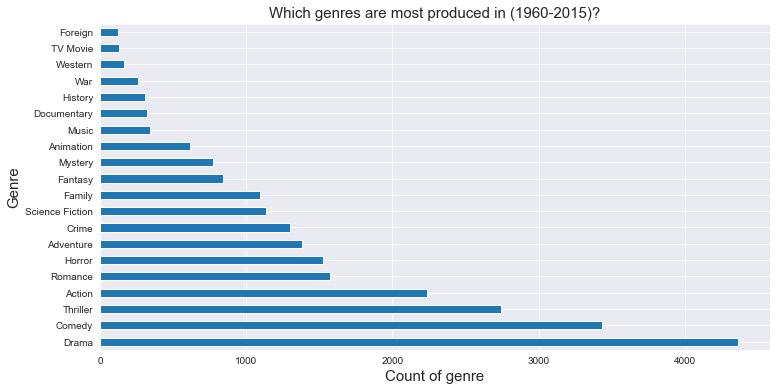

```python
# Most popular genres over years
sns.set_style("darkgrid")
genres_df["genres"].value_counts().plot(kind="barh", figsize=(12,6))
plt.title("Which genres are most produced in ({}-{})?".format(min_year, max_year), fontsize=15)
plt.xlabel("Count of genre", fontsize=15)
plt.ylabel("Genre", fontsize=15)
```

#### Vision:

> Most popular genres from 1960 to 2015 are: Drama, Comedy, Thriller, Action, ... and Foreign.

## Question 2- Top 20 directors who directes most movies?

```python
# This code is to isolate splitted directors in a single file.
# Use this code only if data changed or directors csv file missed.

# Split director values separated by '|'
directors_df = complex_in_year(df, "director")
# Save it as csv file
directors_df.to_csv("Data/year_directors.csv", index=False)
directors_df.shape
```

```
(10708, 3)
```

```python
# Read directors csv to save time.
directors_df = pd.read_csv("Data/year_directors.csv")
directors_df.head()
```

|  | release_year | director | vote_average |
| --- | --- | --- | --- |
| 0 | 1960 | Alfred Hitchcock | 8.000000 |
| 1 | 1960 | John Sturges | 7.000000 |
| 2 | 1960 | Stanley Kubrick | 6.898438 |
| 3 | 1960 | Billy Wilder | 7.898438 |
| 4 | 1960 | George Cukor | 4.898438 |

```python
directors_df.shape
```

```
(10708, 3)
```

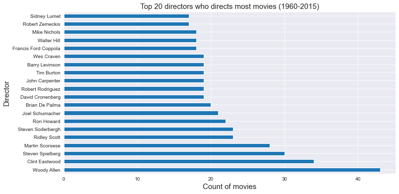

```python
# Select top 20 directors who directs most movies.
top_20_directors = directors_df["director"].value_counts().iloc[:20]

top_20_directors.plot(kind="barh", figsize=(12,6))
plt.title("Top 20 directors who directs most movies ({}-{})".format(min_year, max_year), fontsize=15)
plt.xlabel("Count of movies", fontsize=15)
plt.ylabel("Director", fontsize=15)
```

## Question 3- Top 20 actors who acted in films?

```python
# This code is to isolate splitted cast in a single file.
# Use this code only if data changed or actors csv file is missed.
actors_df = complex_in_year(df, "cast")
actors_df.to_csv("Data/year_actors.csv", index=False)
actors_df.shape
```

```
(48020, 3)
```

```python
# Read actors csv to save time.
actors_df = pd.read_csv("Data/year_actors.csv")
actors_df.shape
```

```
(48020, 3)
```

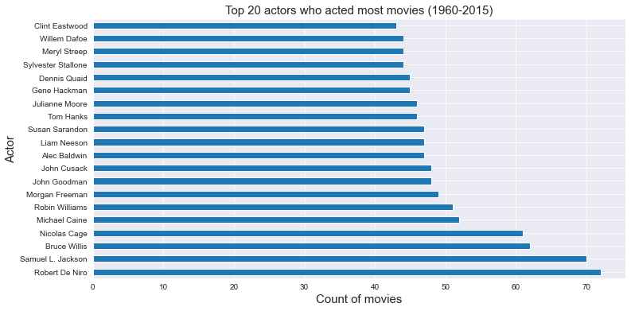

```python
# Select top 20 actors who acted.
top_20_actors = actors_df["cast"].value_counts().iloc[:20]

top_20_actors.plot(kind="barh", figsize=(12,6))
plt.title("Top 20 actors who acted most movies ({}-{})".format(min_year, max_year), fontsize=15)
plt.xlabel("Count of movies", fontsize=15)
plt.ylabel("Actor", fontsize=15)
```

### Vision:

> Top 20 actors who acted most movies are Robert De Niro, Samuel L.Jackson, Bruce Wills, Nicolas Cage, ..., and Clint Estwood.

## َQuestion 4- Top 20 production compaines with higher releases?

```python
# This code is to isolate splitted production_companies in a single file.
# Use this code only if data changed or companies csv file is missed.
companies_df = complex_in_year(df, "production_companies")
companies_df.to_csv("Data/year_companies.csv", index=False)
companies_df.shape
```

```
(23143, 3)
```

```python
# Read companies csv to save time.
companies_df = pd.read_csv("Data/year_companies.csv")
companies_df.shape
```

```
(23143, 3)
```

```python
# Select top 20 companies has releases.
top_20_companies = companies_df["production_companies"].value_counts().iloc[:20]
```

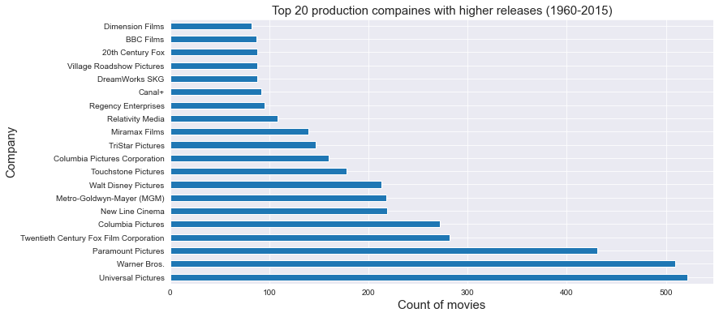

```python
top_20_companies.plot(kind="barh", figsize=(12,6))
plt.title("Top 20 production compaines with higher releases ({}-{})".format(min_year, max_year), fontsize=15)
plt.xlabel("Count of movies", fontsize=15)
plt.ylabel("Company", fontsize=15)
```

### Vision:

> Top 20 production compaines with higher releases are Universal Pictures, Warner Bros, Paramount Pictures, ...., and Dimension Films.

## Question 5- Top&lower 10 movies in budget, revenue, profit, rating, popularity?

```python
# Get a copy of data related to budget and revenue to drop 0 values.
movies_df = (df
[
    [
        "id",
        "original_title",
        "budget",
        "revenue",
        "runtime",
        "profit",
        "vote_count",
        "vote_average",
        "popularity",
        "release_year",
    ]
].copy())

# Drop Nan values.
movies_df.dropna(inplace=True)

# Sort dataframe by budget.
movies_df.sort_values(by="budget", ascending=False, inplace=True)
```

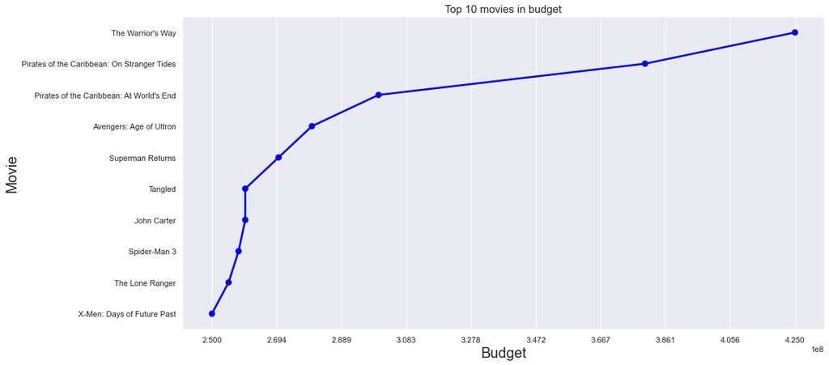

```python
# Top 10 movies in budget.
top = movies_df[["original_title", "budget"]].set_index("original_title").head(10)

x = top.index
y = list(top["budget"])

ax = sns.pointplot(x=y,y=x, color="blue")
sns.set(rc={'figure.figsize':(16,8), "axes.labelsize":15})
ax.set_title("Top 10 movies in budget", fontsize=15)
ax.set_xlabel("Budget", fontsize=20)
ax.set_xticks(np.linspace(min(y), max(y), 10))
ax.set_ylabel("Movie", fontsize=20)
```

### Vision:

> It looks like the top 3 movies in budget are The "Warriors Way", "Pirates of the Caribbean: On Stranger Tides", and "Pirates of the Caribbean: At World's End".

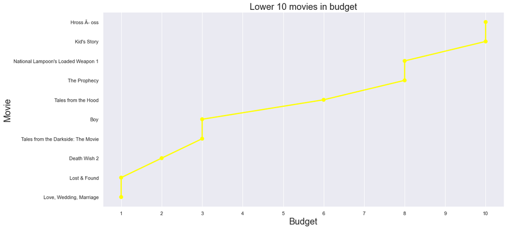

```python
# Lower 10 movies in budget
lower = movies_df[["original_title", "budget"]].set_index("original_title").tail(10)
x = lower.index
y= list(lower["budget"])

ax = sns.pointplot(x=y,y=x, color="yellow")
sns.set(rc={'axes.labelsize':10})
ax.set_xlabel("Budget", fontsize=20)
ax.set_xticks(np.linspace(min(y), max(y), 10))
ax.set_ylabel("Movie", fontsize=20)
ax.set_title("Lower 10 movies in budget", fontsize=20)
```

### Vision:

> It is clear that the lower 3 films in budget are "Love, Wedding, Marriage", "Lost & Found", and "Death Wish 2".

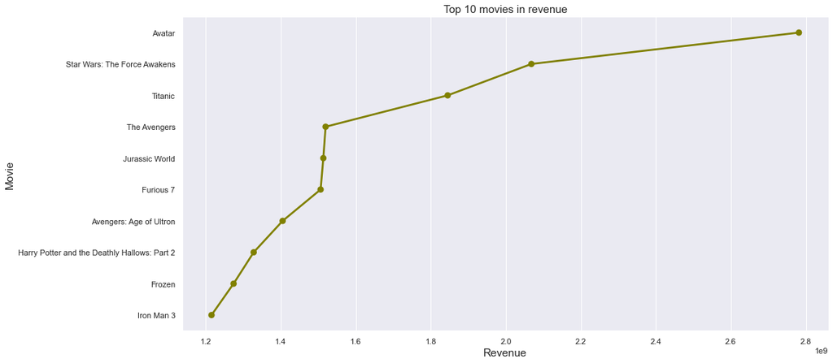

```python
# Sort movies dataframe by revenue.
movies_df.sort_values(by="revenue", ascending=False, inplace=True)
# Top 10 movies in revenue
top = movies_df[["original_title", "revenue"]].set_index("original_title").head(10)

x = top.index
y = list(top["revenue"])

ax = sns.pointplot(x=y, y=x, color="olive")
ax.set_title("Top 10 movies in revenue", fontsize=15)
ax.set_xlabel("Revenue", fontsize=15)
ax.set_ylabel("Movie", fontsize=15)
```

### Vision:

> It is clear that the top 3 films in revenue are "Avatar", "Star Wars: The Force Awakens", and "Titanic".

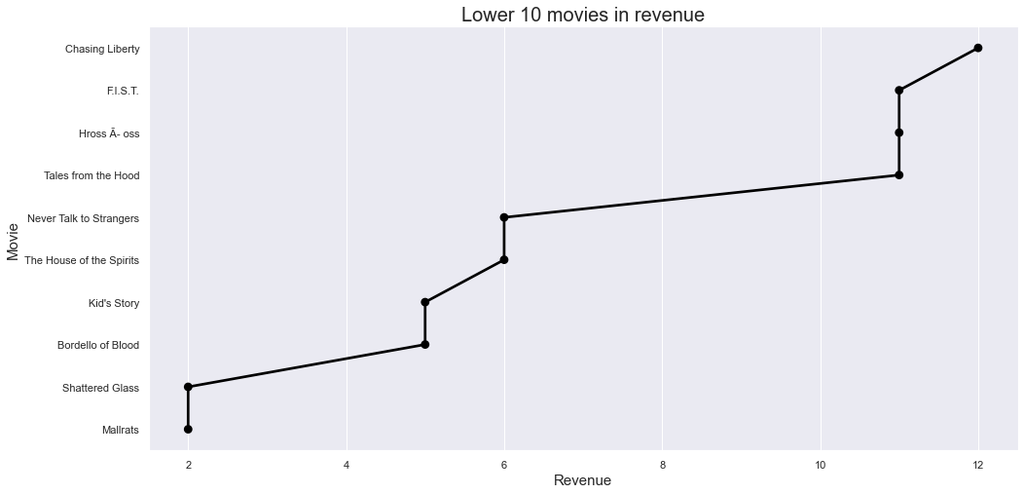

```python
# lower 10 movies in revenue
lower = movies_df[["original_title", "revenue"]].set_index("original_title").tail(10)
x = lower.index
y = list(lower["revenue"])

ax = sns.pointplot(x=y, y=x, color="black")
ax.set_title("Lower 10 movies in revenue", fontsize=20)
ax.set_xlabel("Revenue", fontsize=15)
ax.set_ylabel("Movie", fontsize=15)
```

### Vision:

> It is clear that the lower 3 films in revenue are "Mallrats", "Shattered Glass", and "Bordello of Blood".

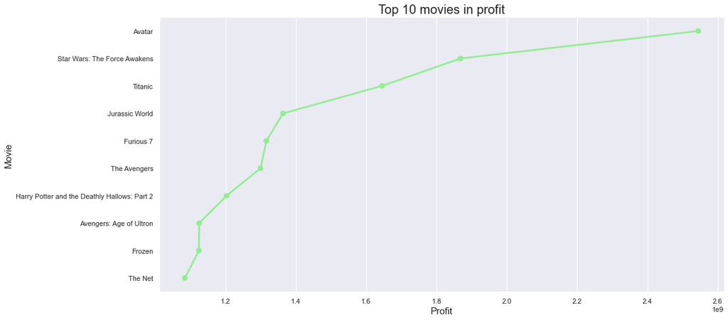

```python
# Sort movies dataframe by profit.
movies_df.sort_values(by="profit", ascending=False, inplace=True)

# Top 10 movies in profit
top = movies_df[["original_title", "profit"]].set_index("original_title").head(10)

x = top.index
y = list(top["profit"])
ax = sns.pointplot(x=y, y=x, color="lightgreen")
ax.set_title("Top 10 movies in profit", fontsize=20)
ax.set_xlabel("Profit", fontsize=15)
ax.set_ylabel("Movie", fontsize=15)
```

### Vision:

> It is clear that the top 3 films in profit are "Avatar", "Star Wars: The Force Awakens", and "Titanic".

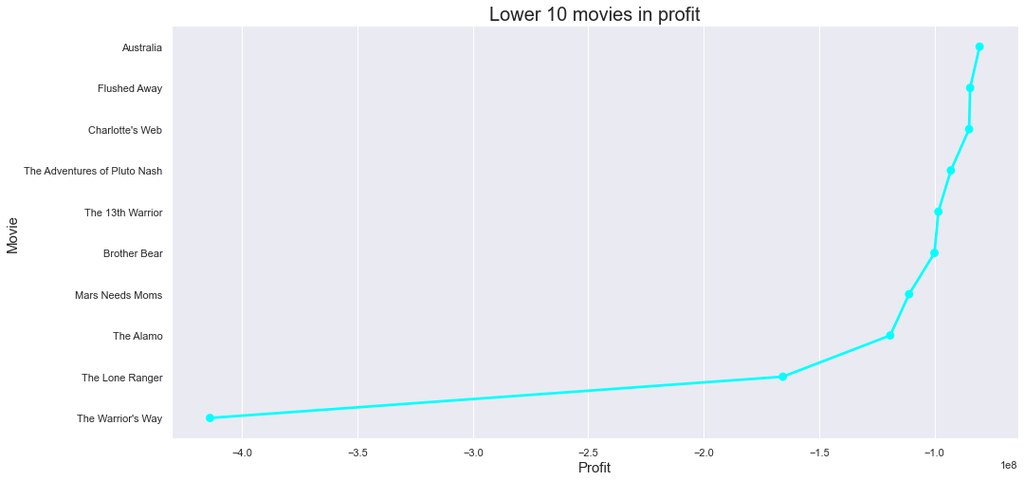

```python
# Lower 10 movies in profit
lower = movies_df[["original_title", "profit"]].set_index("original_title").tail(10)

x = lower.index
y = list(lower["profit"])

ax = sns.pointplot(x=y, y=x, color="aqua")
ax.set_title("Lower 10 movies in profit", fontsize=20)
ax.set_xlabel("Profit", fontsize=15)
ax.set_ylabel("Movie", fontsize=15)
```

### Vision:

> It is clear that the lower 3 films in profit are "The warrior's Way", "The Lone Ranger", and "The Alamo".

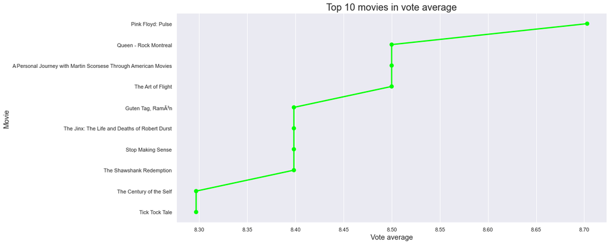

```python
# Get a copy of vote rate of movies and sort it.
movies_rating = df[["original_title", "vote_average"]].copy().sort_values(by="vote_average", ascending=False)
# Top 10 movies in vote average
top = movies_rating.set_index("original_title").head(10)

x = top.index
y = list(top["vote_average"])

ax = sns.pointplot(x=y, y=x, color="lime")
ax.set_title("Top 10 movies in vote average", fontsize=20)
ax.set_xlabel("Vote average", fontsize=15)
ax.set_ylabel("Movie", fontsize=15)
```

### Vision:

> It is clear that the top 3 films in Vote average are "Pink Floyed: Pulse", "Queen-Rock Montreal", and "A Personal Journey with Martin Scorsese Through American Movies".

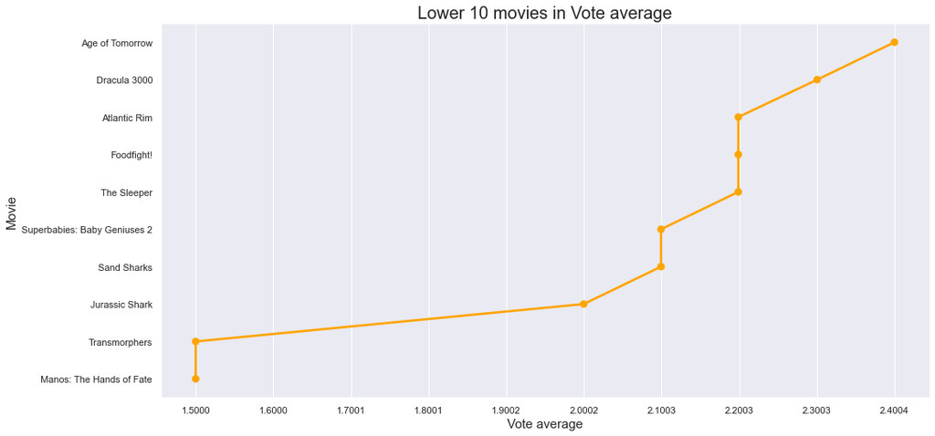

```python
# Lower 10 movies in vote count
lower = movies_rating.set_index("original_title").tail(10)

x = lower.index
y = list(lower["vote_average"])

ax = sns.pointplot(x=y, y=x, color="orange")
ax.set_title("Lower 10 movies in Vote average", fontsize=20)
ax.set_xlabel("Vote average", fontsize=15)
ax.set_xticks(np.linspace(min(y), max(y), 10))
ax.set_ylabel("Movie", fontsize=15)
```

### Vision:

> It is clear that the lower 3 films in vote average are "Manos: The Hands of Fate", "Transmorphers", and "Jurassic Shark".

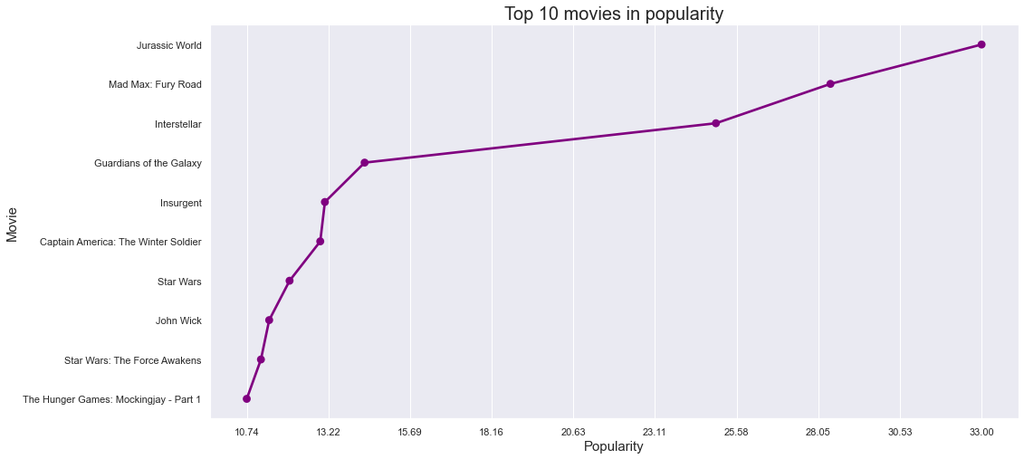

```python
# Get a copy of popularity of movies and sort it.
popular_movies = df[["original_title", "popularity"]].copy().set_index("original_title")
popular_movies.sort_values(by="popularity", ascending = False, inplace=True)

# Top 10 popular movies
top = popular_movies.head(10)

x = top.index
y = list(top["popularity"])

ax = sns.pointplot(x=y, y=x, color="purple")
ax.set_title("Top 10 movies in popularity", fontsize=20)
ax.set_xlabel("Popularity", fontsize=15)
ax.set_xticks(np.linspace(min(y), max(y), 10))
ax.set_ylabel("Movie", fontsize=15)
```

### Vision:

> It is clear that the top 3 films in popularity are "Jurassic World", "Mad Max: Fury Road", and "Interstellar".

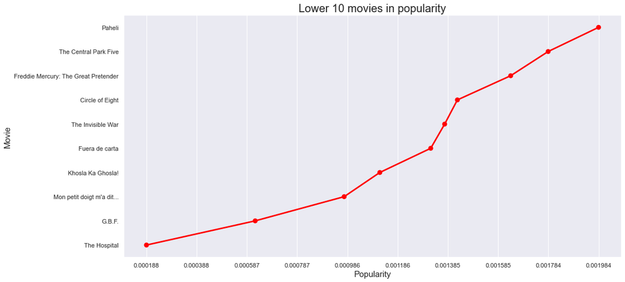

```python
# Lower 10 popular movies/Top 10 unpopular
lower = popular_movies.tail(10)

x = lower.index
y = list(lower["popularity"])

ax = sns.pointplot(x=y, y=x, color="red")
ax.set_title("Lower 10 movies in popularity", fontsize=20)
ax.set_xlabel("Popularity", fontsize=15)
ax.set_xticks(np.linspace(min(y), max(y), 10))
ax.set_ylabel("Movie", fontsize=15)
```

### Vision:

> It is clear that the lower 3 films in popularity are "The Hospital", "G.B.F.", and "Mon petit doigt m'a dit...".

## Question 6- Which year&month has the most releases?

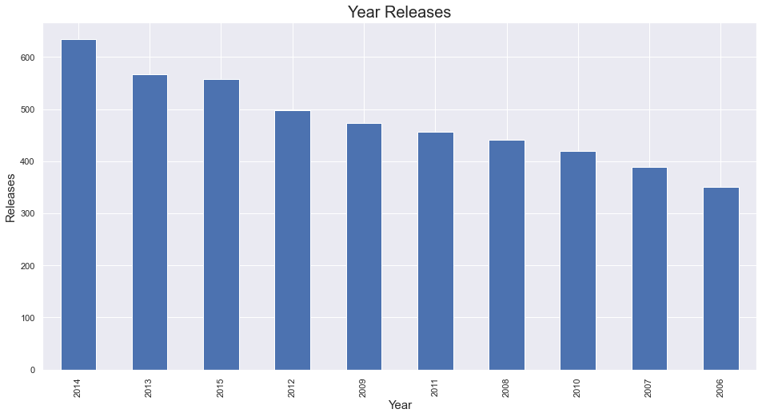

```python
# Get the most year has releases.
year_releases= df["release_year"].value_counts()
year_releases[0:10].plot(kind="bar")
plt.title("Year Releases", fontsize=20)
plt.xlabel("Year", fontsize=15)
plt.ylabel("Releases", fontsize=15)
```

### Vision:

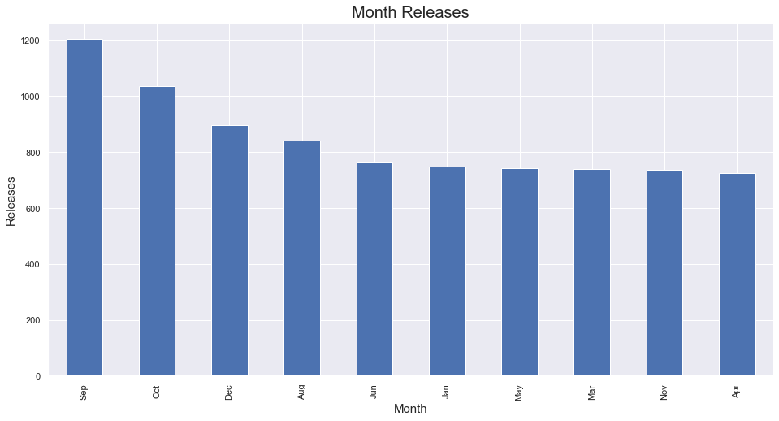

```python
# Get the most month has releases.
month_releases = df["month"].value_counts()

month_releases[0:10].plot(kind="bar")
plt.title("Month Releases", fontsize=20)
plt.xlabel("Month", fontsize=15)
plt.ylabel("Releases", fontsize=15)
```

### Vision:

> As you can see September is the most month has releases, also December and October are following it.

## Question 7- Which year&month has the higher revenue?

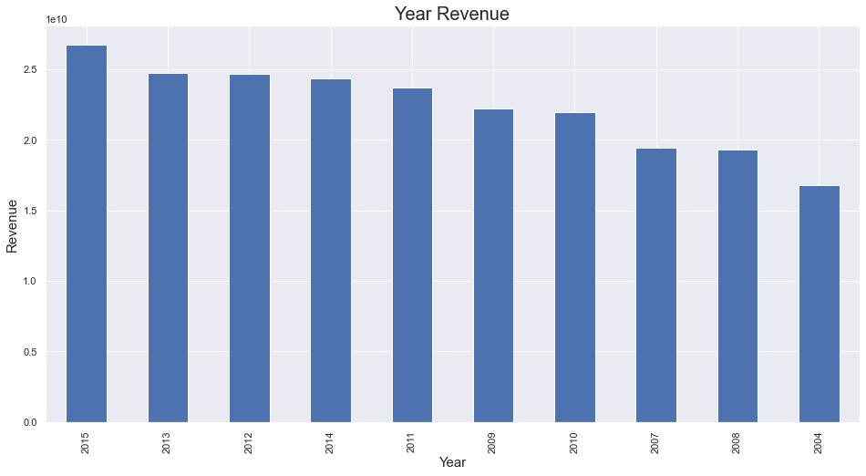

```python
# Find the most year has revenue.
year_revenues = df.groupby("release_year")["revenue"].sum().sort_values(ascending=False)

year_revenues[0:10].plot(kind="bar")
plt.title("Year Revenue", fontsize=20)
plt.xlabel("Year", fontsize=15)
plt.ylabel("Revenue", fontsize=15)
```

### Vision:

> As you can see 15 is the most year has Revenue, also 2013 and 2012 are following it.

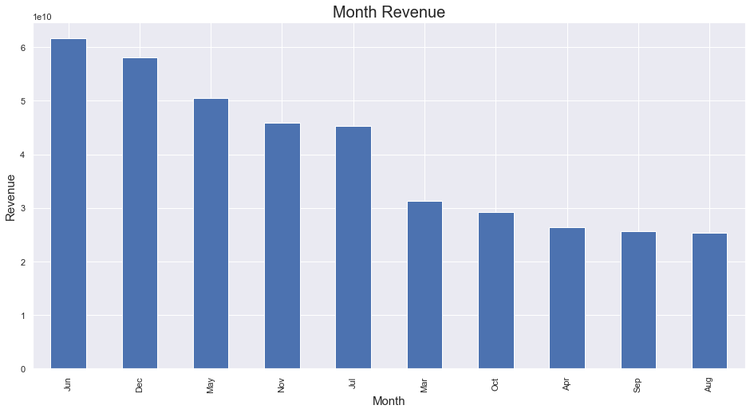

```python
# Find the most month has revenue.
month_revenues = df.groupby("month")["revenue"].sum().sort_values(ascending=False)

month_revenues[0:10].plot(kind="bar")
plt.title("Month Revenue", fontsize=20)
plt.xlabel("Month", fontsize=15)
plt.ylabel("Revenue", fontsize=15)
```

### Vision:

> As you can see Jun is the most month has revenue, also Dec and May are following it.